# PAIRS TRADING WITH A KALMAN FILTER

In this notebook we are going look at the concept of building a trading strategy backtest based on `mean reverting, co-integrated pairs` of assets (Stock and ETFs). So to restate the theory in in terms of US equities, assets that are statistically co-integrated move in a way that means when their prices start to diverge by a certain amount (i.e. the spread between the 2 assets prices increases), we would expect that divergence to eventually revert back to the mean. In this instance we would look to sell the outperforming stock,and buy the under performing stock under the notion that the under performing stock would eventually recover with the over performing stock and rise in price, or vice versa the over performing stock would in time suffer from the same downward pressure of the under performing stock and fall in relative value.

Hence, pairs trading is a market neutral trading strategy enabling traders to profit from virtually any market conditions: Bull Markets, Bear Markets, or Sideways Markets.

So in our search for co-integrated assets, economic theory would suggest that we are more likely to find pairs of that are driven by the same factors, or similar business practices. After all, it is logical to consider 2 assets in the same industry to be similar products, to be at the mercy of the same general ups and downs of the volatile market.

### Kalman Filter

So what is a`Kalman Filter`? Well this site (http://www.bzarg.com/p/how-a-kalman-filter-works-in-pictures/) explains and states the following:

You can use a `Kalman` filter in any place where you have uncertain information about some dynamic system, and you can make an educated guess about what the system is going to do next. Even if messy reality comes along and interferes with the clean motion you guessed about, the Kalman filter will often do a very good job of figuring out what actually happened. And it can take advantage of correlations between crazy phenomena that you maybe wouldn’t have thought to exploit!

Kalman filters are ideal for systems which are continuously changing. They have the advantage that they are light on memory (they don’t need to keep any history other than the previous state), and they are very fast, making them well suited for real time problems and embedded systems.

So lets start to import the relevant modules we will need for our strategy backtest:

# Imports

```python
from time import time
import numpy as np
import matplotlib.pyplot as plt
%matplotlib inline
import matplotlib.cm as cm
from scipy import stats
import datetime as dt
import pandas as pd
import math
import os.path
import time
import json
import requests
import pandas_market_calendars as mcal
from datetime import timedelta, datetime
from dateutil import parser
import seaborn as sns
import matplotlib as mpl
import quantstats as qs
import statsmodels.api as sm
from pykalman import KalmanFilter
from math import sqrt
import warnings
import ffn
import pyfolio as pf
from pandas_datareader import data as web
```

```python
pd.set_option('display.max_columns', None)
warnings.filterwarnings('ignore')
```

## Download ticker data

```python
symbols = ['GDX','GDXJ','GLD', 'AAPL','GOOGL', 'FB','TWTR','AMD',
           'NVDA','CSCO', 'ORCL', 'ATVI', 'TTWO', 'EA', 'HYG',
           'LQD', 'JNK', 'SLV', 'USLV', 'SIVR', 'USO', 'UWT',
           'QQQ', 'SPY', 'VOO', 'VDE', 'VTI', 'EMLP', 'VDC',
           'FSTA', 'KXI', 'IBB', 'VHT','VNQ', 'IYR', 'MSFT',
           'PG', 'TMF', 'UPRO', 'WFC', 'JPM', 'GS', 'CVX',
           'XOM', 'INTC', 'COST', 'WMT', 'T', 'VZ', 'CMCSA', 'AMZN']
```

```python
def get_symbols(symbols,data_source,ohlc,begin_date=None,end_date=None):
    out = []
    new_symbols = []
    for symbol in symbols:
        df = web.DataReader(symbol, data_source,begin_date, end_date)
        df = df[ohlc]
        new_symbols.append(symbol)
        out.append(df.astype('float'))
        data = pd.concat(out, axis = 1)
        data.columns = new_symbols
        data = data.dropna(axis=1)
    return data.dropna(axis=1)
```

```python
start = pd.Timestamp('2014-01-01')
end = pd.Timestamp('2020-03-05')


prices = get_symbols(symbols,data_source='yahoo',ohlc='Close',\
                     begin_date=start,end_date=end)
```

Plot the resulting DataFrame of price data just to make sure we have what we need and as a quick sanity check:

```python
combo = prices.copy()
combo.index = pd.DatetimeIndex(combo.index)
combo.head()
```

| Date | GDX | GDXJ | GLD | AAPL | GOOGL | FB | TWTR | AMD | NVDA | CSCO | ORCL | ATVI | TTWO | EA | HYG | LQD | JNK | SLV | USLV | SIVR | USO | QQQ | SPY | VOO | VDE | VTI | EMLP | VDC | FSTA | … |
| --- | --- | --- | --- | --- | --- | --- | --- | --- | --- | --- | --- | --- | --- | --- | --- | --- | --- | --- | --- | --- | --- | --- | --- | --- | --- | --- | --- | --- | --- | --- |
| 2014-01-02 | 22.030001 | 32.700001 | 118.000000 | 79.018570 | 557.117126 | 54.709999 | 67.500000 | 3.95 | 15.860000 | 22.000000 | 37.840000 | 18.070000 | 17.530001 | 22.830000 | 93.040001 | 114.410004 | 121.589996 | 19.230000 | 489.200012 | 19.719999 | 34.230000 | 87.269997 | 182.919998 | 167.630005 | 124.620003 | 95.080002 | 23.200001 | 108.889999 | 25.809999 | … |
| 2014-01-03 | 21.830000 | 32.650002 | 119.290001 | 77.282860 | 553.053040 | 54.560001 | 69.000000 | 4.00 | 15.670000 | 21.980000 | 37.619999 | 18.290001 | 17.629999 | 22.680000 | 93.010002 | 114.580002 | 121.680000 | 19.420000 | 504.899994 | 19.920000 | 33.750000 | 86.639999 | 182.889999 | 167.479996 | 124.320000 | 95.059998 | 23.190001 | 108.750000 | 25.750000 | … |
| 2014-01-06 | 21.930000 | 32.790001 | 119.500000 | 77.704285 | 559.219238 | 57.200001 | 66.290001 | 4.13 | 15.880000 | 22.010000 | 37.470001 | 18.080000 | 17.600000 | 22.530001 | 93.209999 | 114.830002 | 121.919998 | 19.420000 | 502.100006 | 19.920000 | 33.570000 | 86.320000 | 182.360001 | 167.059998 | 124.290001 | 94.809998 | 23.129999 | 108.269997 | 25.660000 | … |
| 2014-01-07 | 21.969999 | 32.459999 | 118.820000 | 77.148575 | 570.000000 | 57.919998 | 61.459999 | 4.18 | 16.139999 | 22.309999 | 37.849998 | 18.320000 | 18.110001 | 23.100000 | 93.209999 | 114.739998 | 121.949997 | 19.129999 | 480.200012 | 19.610001 | 33.580002 | 87.120003 | 183.479996 | 168.100006 | 125.260002 | 95.419998 | 23.180000 | 108.900002 | 25.799999 | … |
| 2014-01-08 | 21.610001 | 31.709999 | 118.120003 | 77.637146 | 571.186157 | 58.230000 | 59.290001 | 4.18 | 16.360001 | 22.290001 | 37.720001 | 18.340000 | 17.799999 | 23.309999 | 93.150002 | 114.250000 | 121.919998 | 18.830000 | 458.299988 | 19.299999 | 33.160000 | 87.309998 | 183.520004 | 168.169998 | 124.449997 | 95.489998 | 23.110001 | 108.199997 | 25.610001 | … |

```python
combo.info()
```

```
<class 'pandas.core.frame.DataFrame'>
DatetimeIndex: 1555 entries, 2014-01-02 to 2020-03-06
Data columns (total 50 columns):
GDX      1555 non-null float64
GDXJ     1555 non-null float64
GLD      1555 non-null float64
AAPL     1555 non-null float64
GOOGL    1555 non-null float64
FB       1555 non-null float64
TWTR     1555 non-null float64
AMD      1555 non-null float64
NVDA     1555 non-null float64
CSCO     1555 non-null float64
ORCL     1555 non-null float64
ATVI     1555 non-null float64
TTWO     1555 non-null float64
EA       1555 non-null float64
HYG      1555 non-null float64
LQD      1555 non-null float64
JNK      1555 non-null float64
SLV      1555 non-null float64
USLV     1555 non-null float64
SIVR     1555 non-null float64
USO      1555 non-null float64
QQQ      1555 non-null float64
SPY      1555 non-null float64
VOO      1555 non-null float64
VDE      1555 non-null float64
VTI      1555 non-null float64
EMLP     1555 non-null float64
VDC      1555 non-null float64
FSTA     1555 non-null float64
KXI      1555 non-null float64
IBB      1555 non-null float64
VHT      1555 non-null float64
VNQ      1555 non-null float64
IYR      1555 non-null float64
MSFT     1555 non-null float64
PG       1555 non-null float64
TMF      1555 non-null float64
UPRO     1555 non-null float64
WFC      1555 non-null float64
JPM      1555 non-null float64
GS       1555 non-null float64
CVX      1555 non-null float64
XOM      1555 non-null float64
INTC     1555 non-null float64
COST     1555 non-null float64
WMT      1555 non-null float64
T        1555 non-null float64
VZ       1555 non-null float64
CMCSA    1555 non-null float64
AMZN     1555 non-null float64
dtypes: float64(50)
memory usage: 619.6 KB
```

```python
num_stocks = len(combo.columns)
print('Number of Stocks =', num_stocks)
```

```
Number of Stocks = 50
```

# Plot price series

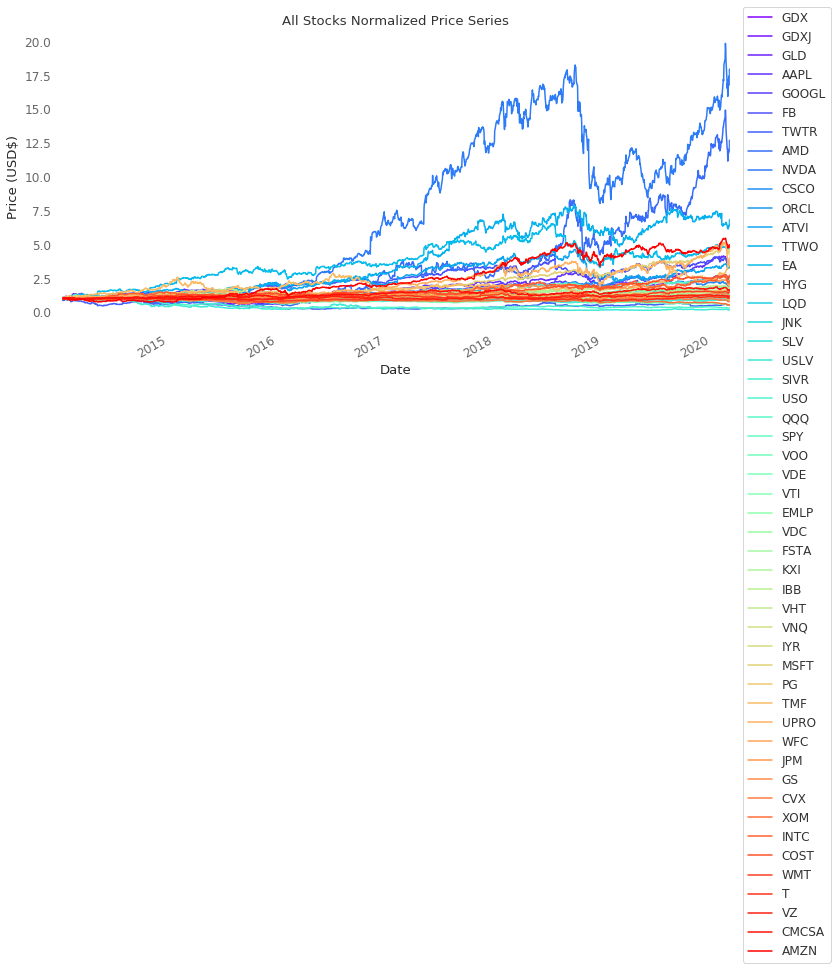

```python
n_secs = len(combo.columns)
colors = cm.rainbow(np.linspace(0, 1, n_secs))
combo.div(combo.iloc[0,:]).plot(color=colors, figsize=(12, 6))# Normalize Prices
plt.title('All Stocks Normalized Price Series')
plt.xlabel('Date')
plt.ylabel('Price (USD$)')
plt.grid(b=None, which=u'major', axis=u'both')
plt.legend(bbox_to_anchor=(1.01, 1.1), loc='upper left', ncol=1)
plt.show();
```

## What Is Cointegration?

The most common test for Pairs Trading is the cointegration test. Cointegration is a statistical property of two or more time-series variables which indicates if a linear combination of the variables is stationary.

`Stationary process:` parameters such as `mean` and `variance` also `do not change` over time.

Ok so it looks from the chart as if we have downloaded price data for around `50` assets; this should be more than enough to find at least a couple of `co-integrated pairs` to run our backtest over.

We will now define a quick function that will run our assets, combining them into pairs one by one and running co-integration tests on each pair. That result will then be stored in a matrix that we initialise, and then we will be able to plot that matrix as a heatmap. Also, if the co-integration test meets our threshold statistical significance (in our case `5%`), then that pair of tickers will be stored in a list for later retrieval.

```python
# NOTE CRITICAL LEVEL HAS BEEN SET TO 5% FOR COINTEGRATION TEST
def find_cointegrated_pairs(dataframe, critial_level = 0.05):
    n = dataframe.shape[1] # the length of dateframe
    pvalue_matrix = np.ones((n, n)) # initialize the matrix of p
    keys = dataframe.columns # get the column names
    pairs = [] # initilize the list for cointegration
    for i in range(n):
        for j in range(i+1, n): # for j bigger than i
            stock1 = dataframe[keys[i]] # obtain the price of "stock1"
            stock2 = dataframe[keys[j]]# obtain the price of "stock2"
            result = sm.tsa.stattools.coint(stock1, stock2) # get conintegration
            pvalue = result[1] # get the pvalue
            pvalue_matrix[i, j] = pvalue
            if pvalue < critial_level: # if p-value less than the critical level
                pairs.append((keys[i], keys[j], pvalue)) # record the contract with that p-value
    return pvalue_matrix, pairs
```

Let’s now run our data through our function, save the results and plot the heatmap:

```python
df = combo

binance_symbols = df.columns

# Set up the split point for our "training data" on which to perform the co-integration test (the remaining dat awill be fed to our backtest function)
split = int(len(df) * 0.3)

# Run our dataframe (up to the split point) of ticker price data through our co-integration function and store results
pvalue_matrix, pairs = find_cointegrated_pairs(df[:split])

# Convert our matrix of stored results into a DataFrame
pvalue_matrix_df = pd.DataFrame(pvalue_matrix)
```

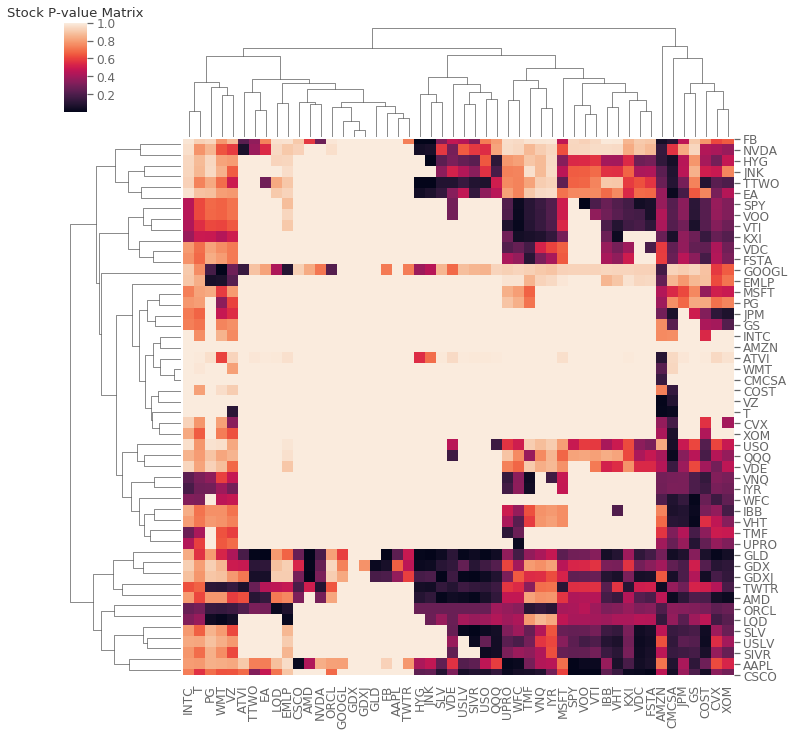

```python
# Use Seaborn to plot a heatmap of our results matrix
sns.clustermap(pvalue_matrix_df, xticklabels=binance_symbols,yticklabels=binance_symbols, figsize=(12, 12))
plt.title('Stock P-value Matrix')
plt.tight_layout()
plt.show();
```

So we can see from the very dark squares that it looks as though there are indeed a few pairs of assets who’s co-integration score is below the `5%` threshold hardcoded into the function we defined. To see more explicitly which pairs these are, let’s print out our list of stored pairs that was part of the fucntion results we stored:

```python
for pair in pairs:
    print("Asset {} and Asset {} has a co-integration score of {}".format(pair[0],pair[1],round(pair[2],4)))
```

```
Asset GDX and Asset GLD has a co-integration score of 0.03
Asset GDX and Asset AMD has a co-integration score of 0.0173
Asset GDX and Asset HYG has a co-integration score of 0.0275
Asset GDX and Asset JNK has a co-integration score of 0.0375
Asset GDXJ and Asset AMD has a co-integration score of 0.0052
Asset GDXJ and Asset SLV has a co-integration score of 0.0062
Asset GDXJ and Asset USLV has a co-integration score of 0.0135
Asset GDXJ and Asset SIVR has a co-integration score of 0.006
Asset GDXJ and Asset USO has a co-integration score of 0.0378
Asset GDXJ and Asset COST has a co-integration score of 0.0495
Asset GLD and Asset FB has a co-integration score of 0.0073
Asset GLD and Asset AMD has a co-integration score of 0.0011
Asset GLD and Asset TTWO has a co-integration score of 0.011
Asset GLD and Asset EA has a co-integration score of 0.0039
Asset GLD and Asset HYG has a co-integration score of 0.0139
Asset GLD and Asset JNK has a co-integration score of 0.0051
Asset GLD and Asset SLV has a co-integration score of 0.0362
Asset GLD and Asset USLV has a co-integration score of 0.0124
Asset GLD and Asset SIVR has a co-integration score of 0.0377
Asset GLD and Asset USO has a co-integration score of 0.0111
Asset GLD and Asset QQQ has a co-integration score of 0.0468
Asset GLD and Asset CVX has a co-integration score of 0.0193
Asset GLD and Asset CMCSA has a co-integration score of 0.0495
Asset AAPL and Asset CSCO has a co-integration score of 0.0237
Asset AAPL and Asset SPY has a co-integration score of 0.005
Asset AAPL and Asset VOO has a co-integration score of 0.0313
Asset AAPL and Asset VTI has a co-integration score of 0.0285
Asset AAPL and Asset VDC has a co-integration score of 0.0483
Asset AAPL and Asset UPRO has a co-integration score of 0.0148
Asset AAPL and Asset WFC has a co-integration score of 0.0273
Asset GOOGL and Asset WMT has a co-integration score of 0.0021
Asset FB and Asset HYG has a co-integration score of 0.0013
Asset FB and Asset JNK has a co-integration score of 0.0033
Asset TWTR and Asset JNK has a co-integration score of 0.0488
Asset TWTR and Asset AMZN has a co-integration score of 0.0424
Asset AMD and Asset SLV has a co-integration score of 0.014
Asset AMD and Asset USLV has a co-integration score of 0.0352
Asset AMD and Asset SIVR has a co-integration score of 0.0141
Asset AMD and Asset VDE has a co-integration score of 0.0459
Asset AMD and Asset XOM has a co-integration score of 0.0352
```

[output cut: 30 more lines]

```
Asset SPY and Asset VOO has a co-integration score of 0.0003
Asset SPY and Asset VDC has a co-integration score of 0.0495
Asset SPY and Asset WFC has a co-integration score of 0.0319
Asset VOO and Asset WFC has a co-integration score of 0.0299
Asset VTI and Asset WFC has a co-integration score of 0.0232
Asset KXI and Asset VHT has a co-integration score of 0.0321
Asset IBB and Asset GS has a co-integration score of 0.0295
Asset VHT and Asset GS has a co-integration score of 0.0185
Asset VNQ and Asset TMF has a co-integration score of 0.04
Asset IYR and Asset TMF has a co-integration score of 0.0494
Asset UPRO and Asset WFC has a co-integration score of 0.03
Asset WFC and Asset GS has a co-integration score of 0.015
Asset T and Asset CMCSA has a co-integration score of 0.0272
Asset T and Asset AMZN has a co-integration score of 0.0148
Asset VZ and Asset AMZN has a co-integration score of 0.0086
```

We will now use the `“pykalman”` module to set up a couple of functions that will allow us to generate Kalman filters which we will apply to our data and in turn our regression that is fed the said data.

```python
def KalmanFilterAverage(x):
  # Construct a Kalman filter
    kf = KalmanFilter(transition_matrices = [1],
    observation_matrices = [1],
    initial_state_mean = 0,
    initial_state_covariance = 1,
    observation_covariance=1,
    transition_covariance=.01)
  # Use the observed values of the price to get a rolling mean
    state_means, _ = kf.filter(x.values)
    state_means = pd.Series(state_means.flatten(), index=x.index)
    return state_means

# Kalman filter regression
def KalmanFilterRegression(x,y):
    delta = 1e-3
    trans_cov = delta / (1 - delta) * np.eye(2) # How much random walk wiggles
    obs_mat = np.expand_dims(np.vstack([[x], [np.ones(len(x))]]).T, axis=1)
    kf = KalmanFilter(n_dim_obs=1, n_dim_state=2, # y is 1-dimensional, (alpha, beta) is 2-dimensional
    initial_state_mean=[0,0],
    initial_state_covariance=np.ones((2, 2)),
    transition_matrices=np.eye(2),
    observation_matrices=obs_mat,
    observation_covariance=2,
    transition_covariance=trans_cov)
    # Use the observations y to get running estimates and errors for the state parameters
    state_means, state_covs = kf.filter(y.values)
    return state_means

def half_life(spread):
    spread_lag = spread.shift(1)
    spread_lag.iloc[0] = spread_lag.iloc[1]
    spread_ret = spread - spread_lag
    spread_ret.iloc[0] = spread_ret.iloc[1]
    spread_lag2 = sm.add_constant(spread_lag)
    model = sm.OLS(spread_ret,spread_lag2)
    res = model.fit()
    halflife = int(round(-np.log(2) / res.params[1],0))
    if halflife <= 0:
        halflife = 1
    return halflife
```

Now let us define our main `“Backtest”` function that we will run our data through. The fucntion takes one pair of tickers at a time, and then returns several outputs, namely the DataFrame of **cumulative returns**, the **Sharpe Ratio** and the **Compound Annual Growth Rate (CAGR)**. Once we have defined our function, we can iterate over our list of pairs and feed the relevant data, pair by pair, into the function, storing the outputs for each pair for later use and retrieval.

```python
def backtest(df,s1, s2):
    #############################################################
    # INPUT:
    # DataFrame of prices (df)
    # s1: the symbol of asset one
    # s2: the symbol of asset two
    # x: the price series of asset one
    # y: the price series of asset two
    # OUTPUT:
    # df1['cum rets']: cumulative returns in pandas data frame
    # sharpe: Sharpe ratio
    # CAGR: Compound Annual Growth Rate

    x = df[s1]
    y = df[s2]

    # Run regression (including Kalman Filter) to find hedge ratio and then create spread series
    df1 = pd.DataFrame({'y':y,'x':x})
    df1.index = pd.to_datetime(df1.index)
    state_means = KalmanFilterRegression(KalmanFilterAverage(x),KalmanFilterAverage(y))
    df1['hr'] = - state_means[:,0]
    df1['spread'] = df1.y + (df1.x * df1.hr)

    # calculate half life
    halflife = half_life(df1['spread'])

    # calculate z-score with window = half life period
    meanSpread = df1.spread.rolling(window=halflife).mean()
    stdSpread = df1.spread.rolling(window=halflife).std()
    df1['zScore'] = (df1.spread-meanSpread)/stdSpread

    ##############################################################

    # trading logic
    entryZscore = 1.25
    exitZscore = -0.08

    #set up num units long
    df1['long entry'] = ((df1.zScore < - entryZscore) & ( df1.zScore.shift(1) > - entryZscore))
    df1['long exit'] = ((df1.zScore > - exitZscore) & (df1.zScore.shift(1) < - exitZscore))
    df1['num units long'] = np.nan
    df1.loc[df1['long entry'],'num units long'] = 1
    df1.loc[df1['long exit'],'num units long'] = 0
    df1['num units long'][0] = 0
    df1['num units long'] = df1['num units long'].fillna(method='pad')

    #set up num units short
    df1['short entry'] = ((df1.zScore > entryZscore) & ( df1.zScore.shift(1) < entryZscore))
    df1['short exit'] = ((df1.zScore < exitZscore) & (df1.zScore.shift(1) > exitZscore))
    df1.loc[df1['short entry'],'num units short'] = -1
    df1.loc[df1['short exit'],'num units short'] = 0
    df1['num units short'][0] = 0
    df1['num units short'] = df1['num units short'].fillna(method='pad')

    #set up totals: num units and returns
    df1['numUnits'] = df1['num units long'] + df1['num units short']
    df1['spread pct ch'] = (df1['spread'] - df1['spread'].shift(1)) / ((df1['x'] * abs(df1['hr'])) + df1['y'])
    df1['port rets'] = df1['spread pct ch'] * df1['numUnits'].shift(1)
    df1['cum rets'] = df1['port rets'].cumsum()
    df1['cum rets'] = df1['cum rets'] + 1

    ##############################################################

    try:
        sharpe = ((df1['port rets'].mean() / df1['port rets'].std()) * sqrt(252))
    except ZeroDivisionError:
        sharpe = 0.0

    ##############################################################

    start_val = 1
    end_val = df1['cum rets'].iat[-1]
    start_date = df1.iloc[0].name
    end_date = df1.iloc[-1].name
    days = (end_date - start_date).days
    CAGR = (end_val / start_val) ** (252.0/days) - 1

    df1[s1+ " "+s2+'_cum_rets'] = df1['cum rets']

    return df1[s1+ " "+s2+'_cum_rets'], sharpe, CAGR
```

So now let’s run our full list of pairs through our Backtest function, and print out some results along the way, and finally after storing the equity curve for each pair, produce a chart that plots out each curve.

```python
results = []
for pair in pairs:
    rets, sharpe, CAGR = backtest(df[split:],pair[0],pair[1])
    results.append(rets)
    print("The pair {} and {} produced a Sharpe Ratio of {} and a CAGR of {}".format(pair[0],pair[1],
                                                                                     round(sharpe,2),
                                                                                     round(CAGR,4)))
    rets0 = pd.concat(results, axis=1)
```

```
The pair GDX and GLD produced a Sharpe Ratio of 0.52 and a CAGR of 0.0312
The pair GDX and AMD produced a Sharpe Ratio of 1.08 and a CAGR of 0.154
The pair GDX and HYG produced a Sharpe Ratio of 0.4 and a CAGR of 0.0345
The pair GDX and JNK produced a Sharpe Ratio of 0.76 and a CAGR of 0.0611
The pair GDXJ and AMD produced a Sharpe Ratio of 0.93 and a CAGR of 0.1373
The pair GDXJ and SLV produced a Sharpe Ratio of 0.55 and a CAGR of 0.0391
The pair GDXJ and USLV produced a Sharpe Ratio of 0.5 and a CAGR of 0.056
The pair GDXJ and SIVR produced a Sharpe Ratio of 0.68 and a CAGR of 0.0473
The pair GDXJ and USO produced a Sharpe Ratio of 0.67 and a CAGR of 0.0756
The pair GDXJ and COST produced a Sharpe Ratio of 0.82 and a CAGR of 0.0816
The pair GLD and FB produced a Sharpe Ratio of 1.46 and a CAGR of 0.0963
The pair GLD and AMD produced a Sharpe Ratio of 1.37 and a CAGR of 0.1579
The pair GLD and TTWO produced a Sharpe Ratio of 1.57 and a CAGR of 0.1134
The pair GLD and EA produced a Sharpe Ratio of 1.52 and a CAGR of 0.1032
The pair GLD and HYG produced a Sharpe Ratio of 1.15 and a CAGR of 0.0398
The pair GLD and JNK produced a Sharpe Ratio of 1.14 and a CAGR of 0.0404
The pair GLD and SLV produced a Sharpe Ratio of 0.48 and a CAGR of 0.0162
The pair GLD and USLV produced a Sharpe Ratio of 0.92 and a CAGR of 0.1008
The pair GLD and SIVR produced a Sharpe Ratio of 0.72 and a CAGR of 0.0238
The pair GLD and USO produced a Sharpe Ratio of 1.22 and a CAGR of 0.0893
The pair GLD and QQQ produced a Sharpe Ratio of 1.23 and a CAGR of 0.0632
The pair GLD and CVX produced a Sharpe Ratio of 0.65 and a CAGR of 0.0394
The pair GLD and CMCSA produced a Sharpe Ratio of 2.09 and a CAGR of 0.106
The pair AAPL and CSCO produced a Sharpe Ratio of 1.53 and a CAGR of 0.0791
The pair AAPL and SPY produced a Sharpe Ratio of 0.95 and a CAGR of 0.0433
The pair AAPL and VOO produced a Sharpe Ratio of 0.83 and a CAGR of 0.0377
The pair AAPL and VTI produced a Sharpe Ratio of 1.01 and a CAGR of 0.0466
The pair AAPL and VDC produced a Sharpe Ratio of 1.22 and a CAGR of 0.0646
The pair AAPL and UPRO produced a Sharpe Ratio of 0.61 and a CAGR of 0.0441
The pair AAPL and WFC produced a Sharpe Ratio of 1.08 and a CAGR of 0.0655
The pair GOOGL and WMT produced a Sharpe Ratio of 2.07 and a CAGR of 0.1078
The pair FB and HYG produced a Sharpe Ratio of 1.2 and a CAGR of 0.0695
The pair FB and JNK produced a Sharpe Ratio of 1.5 and a CAGR of 0.0866
The pair TWTR and JNK produced a Sharpe Ratio of 0.57 and a CAGR of 0.0627
The pair TWTR and AMZN produced a Sharpe Ratio of 1.11 and a CAGR of 0.1073
The pair AMD and SLV produced a Sharpe Ratio of 1.18 and a CAGR of 0.1396
The pair AMD and USLV produced a Sharpe Ratio of 1.1 and a CAGR of 0.1823
The pair AMD and SIVR produced a Sharpe Ratio of 1.15 and a CAGR of 0.137
The pair AMD and VDE produced a Sharpe Ratio of 0.95 and a CAGR of 0.1074
The pair AMD and XOM produced a Sharpe Ratio of 1.31 and a CAGR of 0.139
```

[output cut: 30 more lines]

```
The pair SPY and VOO produced a Sharpe Ratio of 0.0 and a CAGR of 0.0
The pair SPY and VDC produced a Sharpe Ratio of 1.16 and a CAGR of 0.0287
The pair SPY and WFC produced a Sharpe Ratio of 1.17 and a CAGR of 0.0452
The pair VOO and WFC produced a Sharpe Ratio of 1.08 and a CAGR of 0.0429
The pair VTI and WFC produced a Sharpe Ratio of 1.23 and a CAGR of 0.0474
The pair KXI and VHT produced a Sharpe Ratio of 0.81 and a CAGR of 0.0265
The pair IBB and GS produced a Sharpe Ratio of 0.83 and a CAGR of 0.0459
The pair VHT and GS produced a Sharpe Ratio of 1.23 and a CAGR of 0.0558
The pair VNQ and TMF produced a Sharpe Ratio of 1.69 and a CAGR of 0.1227
The pair IYR and TMF produced a Sharpe Ratio of 1.8 and a CAGR of 0.1247
The pair UPRO and WFC produced a Sharpe Ratio of 0.61 and a CAGR of 0.0456
The pair WFC and GS produced a Sharpe Ratio of 1.43 and a CAGR of 0.0618
The pair T and CMCSA produced a Sharpe Ratio of 1.47 and a CAGR of 0.0732
The pair T and AMZN produced a Sharpe Ratio of 1.34 and a CAGR of 0.0897
The pair VZ and AMZN produced a Sharpe Ratio of 1.23 and a CAGR of 0.0858
```

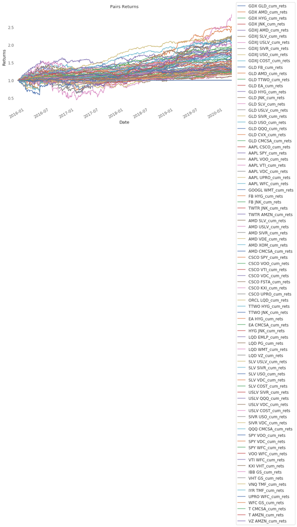

```python
rets0.plot(figsize=(12,6),legend=True)
plt.legend(bbox_to_anchor=(1.01, 1.1), loc='upper left', ncol=1)
plt.grid(b=None, which=u'major', axis=u'both')
plt.title('Pairs Returns')
plt.xlabel('Date')
plt.ylabel('Returns');
```

Now we run a few extra lines of code to combine, equally weight, and print our our final equity curve:

```python
filename = 'pairs_rets.csv'
rets0.to_csv(filename)
```

```python
#concatenate together the individual equity curves into a single DataFrame
results_df = pd.concat(results,axis=1).dropna()

#equally weight each equity curve by dividing each by the number of pairs held in the DataFrame
results_df /= len(results_df.columns)

#sum up the equally weighted equity curves to get our final equity curve
final_res = results_df.sum(axis=1)

# square root of sample size for correct number of bins for returns distribution
print('Bin Count =', np.sqrt(len(final_res)))
```

```
Bin Count = 32.984845004941285
```

```python
Pair_Rets = ffn.to_returns(final_res)
Pair_Rets = pd.DataFrame(Pair_Rets)
Pair_Rets = Pair_Rets.fillna(0)
Pair_Rets.columns = ['Pairs_Returns']
```

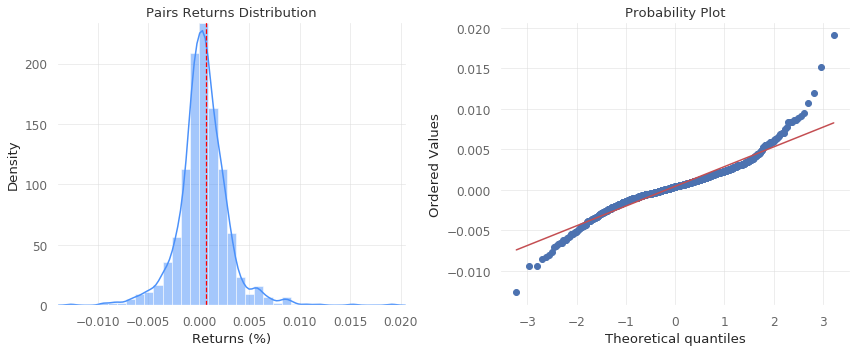

```python
fig, (ax1, ax2) = plt.subplots(1,2,figsize=(12, 5))

sns.distplot(Pair_Rets, hist = True, kde = True, bins=35,
                 hist_kws = {'linewidth': 1, 'alpha':.5},
                 label='Pairs Returns', color='#4b91fa', ax=ax1)

ax1.axvline(x=0.000709, color='#ff0000', linewidth=1.25, linestyle='dashed',label = 'Returns Mean')

ax1.set_title('Pairs Returns Distribution')
ax1.margins(0.001)
ax1.set_xlabel('Returns (%)')
ax1.set_ylabel('Density')

stats.probplot(Pair_Rets.Pairs_Returns, plot=ax2)

plt.tight_layout()

plt.show();
```

```python
Pair_Rets.Pairs_Returns.describe()
```

```
count    1088.000000
mean        0.000423
std         0.002528
min        -0.012679
25%        -0.000744
50%         0.000390
75%         0.001607
max         0.019094
Name: Pairs_Returns, dtype: float64
```

```python
perf = final_res.calc_stats()
```

```python
num_pairs = len(results_df.columns)
print('Number of Pairs =', num_pairs)
```

```
Number of Pairs = 85
```

```python
# set SPY as benchmark
bench = df.loc[str(Pair_Rets.index[0]):str(Pair_Rets.index[-1])].SPY.pct_change().dropna()
Pair_Rets0 = Pair_Rets.loc[str(bench.index[0]):str(bench.index[-1])]
```

### Total Returns Performance

| Start date End date Total months | 2015-11-10 2020-03-06 51 Backtest | 2015-11-10 2020-03-06 51 |
| --- | --- | --- |
| Annual return | 11.2% |  |
| Cumulative returns | 57.9% |  |
| Annual volatility | 4.0% |  |
| Sharpe ratio | 2.66 |  |
| Calmar ratio | 2.80 |  |
| Stability | 0.93 |  |
| Max drawdown | -4.0% |  |
| Omega ratio | 1.63 |  |
| Sortino ratio | 4.39 |  |
| Skew | 0.50 |  |
| Kurtosis | 6.13 |  |
| Tail ratio | 1.20 |  |
| Daily value at risk | -0.5% |  |
| Alpha | 0.11 |  |
| Beta | 0.02 |  |

| Worst drawdown periods | Net drawdown in % | Peak date | Valley date | Recovery date | Duration |
| --- | --- | --- | --- | --- | --- |
| 0 | 3.99 | 2016-06-28 | 2017-01-17 | 2017-08-02 | 287 |
| 1 | 1.90 | 2016-05-06 | 2016-06-15 | 2016-06-24 | 36 |
| 2 | 1.88 | 2016-02-18 | 2016-03-01 | 2016-03-16 | 20 |
| 3 | 1.83 | 2016-01-05 | 2016-01-07 | 2016-01-27 | 17 |
| 4 | 1.42 | 2016-02-02 | 2016-02-11 | 2016-02-16 | 11 |

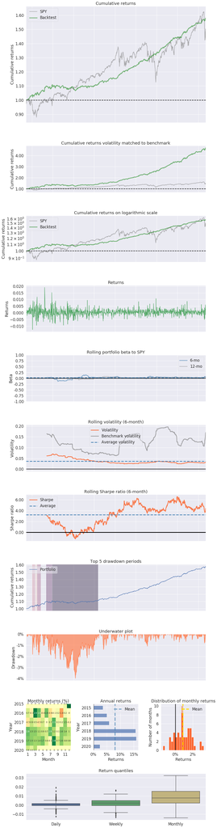

```python
fig = pf.create_returns_tear_sheet(Pair_Rets.Pairs_Returns, benchmark_rets=bench)
```

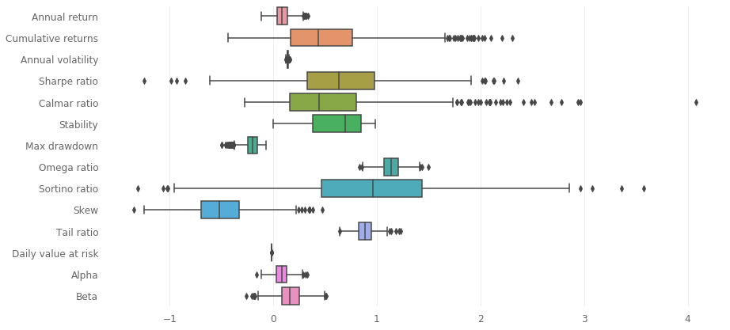

```python
plt.figure(figsize=(14, 7))
pf.plot_perf_stats(factor_returns=Pair_Rets.Pairs_Returns, returns=bench)
plt.show();
```

```python
qs.extend_pandas()
stock = Pair_Rets.Pairs_Returns
```

```python
#qs.reports.html(stock, "SPY", title='Kalman Filter Pairs Strategy')
```